# Live births in Scotland 2022

# Plotting the map

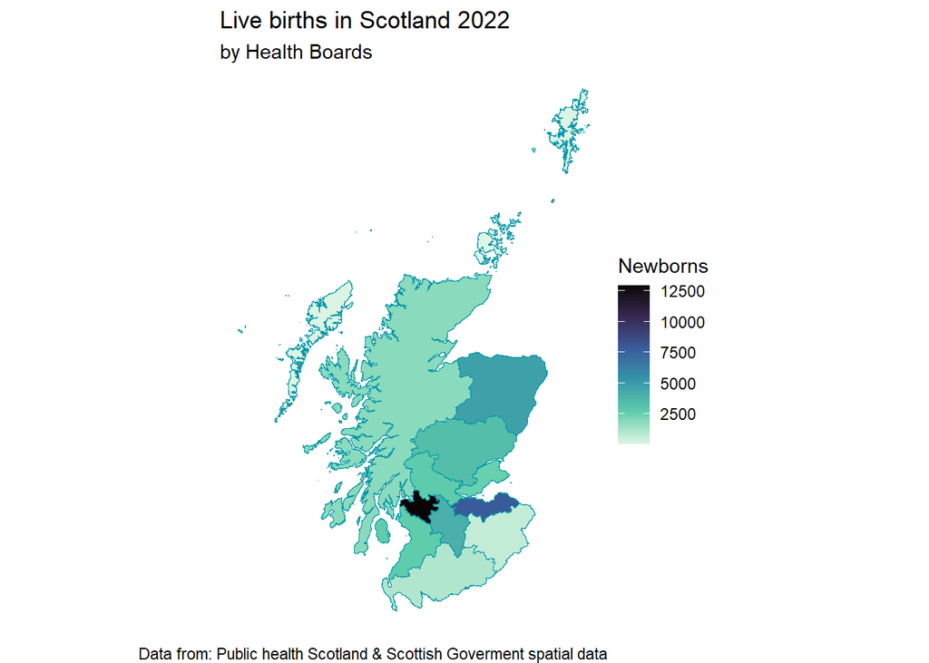

```r
baby2022_map <- ggplot(births_spatial, aes(fill = Newborns)) +
  geom_sf(size = 0.1, color = "#0097a7") +
  scale_fill_viridis_c(option = "mako", direction = -1) +
    labs(
    title = "Live births in Scotland 2022",
    subtitle = "by Health Boards",
    caption="Data from: Public health Scotland & Scottish Goverment spatial data") +
  coord_sf() +
  theme_void()
baby2022_map
```

See more data fun and drawings in the author´s website [www.inmaruiz.com](https://inmaruiz.com/index.php/machine-learning/)

### Software and packages used (or not used, but mentioned alt least)

**R:** R Core Team (2022). R: A language and environment for statistical computing. R Foundation for Statistical Computing, Vienna, Austria. URLcitatiohttps://www.R-project.org/.

**janitor:** Firke S (2021). *janitor: Simple Tools for Examining and Cleaning Dirty Data*. R package version 2.1.0, https://CRAN.R-project.org/package=janitor..

**Tidyverse:** Wickham H, Averick M, Bryan J, Chang W, McGowan LD, François R, Grolemund G, Hayes A, Henry L, Hester J, Kuhn M, Pedersen TL, Miller E, Bache SM, Müller K, Ooms J, Robinson D, Seidel DP, Spinu V, Takahashi K, Vaughan D, Wilke C, Woo K, Yutani H (2019). “Welcome to the tidyverse.” *Journal of Open Source Software*, *4*(43), 1686. doi:10.21105/joss.01686 https://doi.org/10.21105/joss.01686.

**Knitr:** Yihui Xie (2022). knitr: A General-Purpose Package for Dynamic Report Generation in R. R package version 1.40. H. Wickham. ggplot2: Elegant Graphics for Data Analysis. Springer-Verlag New York, 2016

**kableExtra:** Zhu H (2021). *kableExtra: Construct Complex Table with ‘kable’ and Pipe Syntax*. R package version 1.3.4, https://CRAN.R-project.org/package=kableExtra.

**ggplot:** H. Wickham. ggplot2: Elegant Graphics for Data Analysis. Springer-Verlag New York, 2016

**formatR** Xie Y (2023). *formatR: Format R Code Automatically*. R package version 1.14, https://CRAN.R-project.org/package=formatR.

**lubridate** Garrett Grolemund, Hadley Wickham (2011). Dates and Times Made Easy with lubridate. Journal of Statistical Software, 40(3), 1-25. URL https://www.jstatsoft.org/v40/i03/.

**rgdal** Bivand R, Keitt T, Rowlingson B (2023). *rgdal: Bindings for the ‘Geospatial’ Data Abstraction Library*. R package version 1.6-4, https://CRAN.R-project.org/package=rgdal.

**sp** Pebesma, E.J., R.S. Bivand, 2005. Classes and methods for spatial data in R. R News 5 (2), https://cran.r-project.org/doc/Rnews/. Roger S. Bivand, Edzer Pebesma, Virgilio Gomez-Rubio, 2013. Applied spatial data analysis with R, Second edition. Springer, NY. https://asdar-book.org/

**sf** Pebesma, E., 2018. Simple Features for R: Standardized Support for Spatial Vector Data. The R Journal 10 (1), 439-446, https://doi.org/10.32614/RJ-2018-00.

**gridExtra** Auguie B (2017). *gridExtra: Miscellaneous Functions for “Grid” Graphics*. R package version 2.3, https://CRAN.R-project.org/package=gridExtra.

**laticeExtra** Sarkar D, Andrews F (2022). *latticeExtra: Extra Graphical Utilities Based on Lattice*. R package version 0.6-30, https://CRAN.R-project.org/package=latticeExtra.

**cowplot** Wilke C (2020). *cowplot: Streamlined Plot Theme and Plot Annotations for ‘ggplot2’*. R package version 1.1.1, https://CRAN.R-project.org/package=cowplot.

[Spatial Data Metadata Portal](https://spatialdata.gov.scot/geonetwork/srv/eng/catalog.search#/home), Scotland’s catalogue of spatial data.